# cfMeDIP-seq: Protocol, Pipeline, and Classifier Methodologies

claude.ai Opus 4.5 with naive prompts from [Francois Collin](https://www.linkedin.com/in/francoisz/)

May 15, 2026

## Executive Summary

This document provides comprehensive technical details on the cell-free methylated DNA immunoprecipitation and high-throughput sequencing (cfMeDIP-seq) methodology, including:

1. The initial protocol as described in Shen et al., Nature Protocols 2019 [1]
2. Sources of technical variability in the protocol
3. The MEDIPIPE computational analysis pipeline
4. Machine l/earning classifiers developed for cancer detection
5. Protocol and classifier improvements over time

# 1 Protocol: cfMeDIP-seq (Nature Protocols 2019) [1]

## 1.1 Overview

The cfMeDIP-seq protocol was published by Shen, Burgener, Bratman, and De Carvalho in Nature Protocols (2019) [1] as an adaptation of conventional MeDIP-seq for low-input cell-free DNA samples. The protocol enables methylome profiling from 1-10 ng of input DNA through the addition of “filler DNA” before immunoprecipitation.

**Timeline**: The protocol can be completed in approximately 3-4 days by a standard molecular biology laboratory.

**Key Innovation**: Addition of filler DNA (unmethylated lambda phage DNA or methylated genomic DNA) acts as a carrier to improve the efficiency and specificity of antibody-mediated capture of methylated cfDNA fragments.

## 1.2 **Sample Prep and Sequencing Protocol**

The cfMeDIP-seq protocol consists of four major stages:

### Home

### Flowchart

- Protocol Flowchart

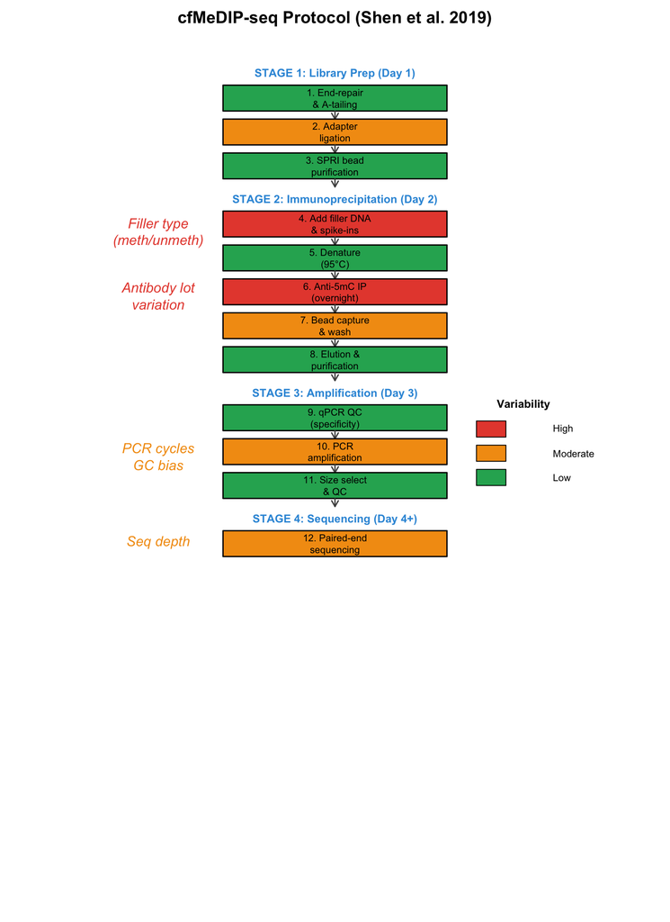

```r
###, fig.cap="cfMeDIP-seq Protocol (Shen et al. 2019)"}

# Set up plotting area
par(mar = c(1, 1, 2, 1))
plot(NULL, xlim = c(0, 10), ylim = c(0, 100),
     xlab = "", ylab = "", xaxt = "n", yaxt = "n",
     bty = "n", main = "cfMeDIP-seq Protocol (Shen et al. 2019)")

# Color scheme for variability
col_high <- "#E74C3C"      # Red - HIGH variability
col_mod <- "#F39C12"       # Orange - MODERATE variability
col_low <- "#27AE60"       # Green - LOW variability
col_stage <- "#3498DB"     # Blue - Stage headers

# Function to draw a box with text
draw_box <- function(x, y, w, h, label, fill_col, text_cex = 0.7) {
  rect(x - w/2, y - h/2, x + w/2, y + h/2, col = fill_col, border = "black", lwd = 1.5)
  text(x, y, label, cex = text_cex, font = 1)
}

# Function to draw arrow between boxes
draw_arrow <- function(x1, y1, x2, y2) {
  arrows(x1, y1, x2, y2, length = 0.08, lwd = 1.5, col = "gray30")
}

# Function to draw stage header
draw_stage <- function(x, y, label) {
  text(x, y, label, cex = 0.8, font = 2, col = col_stage)
}

# Layout parameters
cx <- 5          # Center x
bw <- 3.8        # Box width
bh <- 3.2        # Box height
gap <- 4.2       # Vertical gap between boxes

# Starting y position
###y_pos <- 96
y_pos <- 99

# === STAGE 1: Library Preparation ===
draw_stage(cx, y_pos, "STAGE 1: Library Prep (Day 1)")
y_pos <- y_pos - 3

draw_box(cx, y_pos, bw, bh, "1. End-repair\n& A-tailing", col_low)
y_pos <- y_pos - gap
draw_arrow(cx, y_pos + gap - bh/2, cx, y_pos + bh/2)

draw_box(cx, y_pos, bw, bh, "2. Adapter\nligation", col_mod)
y_pos <- y_pos - gap
draw_arrow(cx, y_pos + gap - bh/2, cx, y_pos + bh/2)

draw_box(cx, y_pos, bw, bh, "3. SPRI bead\npurification", col_low)
y_pos <- y_pos - gap - 1
draw_arrow(cx, y_pos + gap + 1 - bh/2, cx, y_pos + bh/2 + 1)

# === STAGE 2: Immunoprecipitation ===
draw_stage(cx, y_pos + 1, "STAGE 2: Immunoprecipitation (Day 2)")
y_pos <- y_pos - 2

draw_box(cx, y_pos, bw, bh, "4. Add filler DNA\n& spike-ins", col_high)
y_pos <- y_pos - gap
draw_arrow(cx, y_pos + gap - bh/2, cx, y_pos + bh/2)

draw_box(cx, y_pos, bw, bh, "5. Denature\n(95°C)", col_low)
y_pos <- y_pos - gap
draw_arrow(cx, y_pos + gap - bh/2, cx, y_pos + bh/2)

draw_box(cx, y_pos, bw, bh, "6. Anti-5mC IP\n(overnight)", col_high)
y_pos <- y_pos - gap
draw_arrow(cx, y_pos + gap - bh/2, cx, y_pos + bh/2)

draw_box(cx, y_pos, bw, bh, "7. Bead capture\n& wash", col_mod)
y_pos <- y_pos - gap
draw_arrow(cx, y_pos + gap - bh/2, cx, y_pos + bh/2)

draw_box(cx, y_pos, bw, bh, "8. Elution &\npurification", col_low)
y_pos <- y_pos - gap - 1
draw_arrow(cx, y_pos + gap + 1 - bh/2, cx, y_pos + bh/2 + 1)

# === STAGE 3: Amplification ===
draw_stage(cx, y_pos + 1, "STAGE 3: Amplification (Day 3)")
y_pos <- y_pos - 2

draw_box(cx, y_pos, bw, bh, "9. qPCR QC\n(specificity)", col_low)
y_pos <- y_pos - gap
draw_arrow(cx, y_pos + gap - bh/2, cx, y_pos + bh/2)

draw_box(cx, y_pos, bw, bh, "10. PCR\namplification", col_mod)
y_pos <- y_pos - gap
draw_arrow(cx, y_pos + gap - bh/2, cx, y_pos + bh/2)

draw_box(cx, y_pos, bw, bh, "11. Size select\n& QC", col_low)
y_pos <- y_pos - gap - 1
draw_arrow(cx, y_pos + gap + 1 - bh/2, cx, y_pos + bh/2 + 1)

# === STAGE 4: Sequencing ===
draw_stage(cx, y_pos + 1, "STAGE 4: Sequencing (Day 4+)")
y_pos <- y_pos - 2

draw_box(cx, y_pos, bw, bh, "12. Paired-end\nsequencing", col_mod)

# === LEGEND ===
legend_x <- 8.2
legend_y <- 50

text(legend_x, legend_y + 8, "Variability", font = 2, cex = 0.8)
rect(legend_x - 0.8, legend_y + 4, legend_x - 0.3, legend_y + 6, col = col_high, border = "black")
text(legend_x + 0.5, legend_y + 5, "High", cex = 0.7, adj = 0)
rect(legend_x - 0.8, legend_y + 1, legend_x - 0.3, legend_y + 3, col = col_mod, border = "black")
text(legend_x + 0.5, legend_y + 2, "Moderate", cex = 0.7, adj = 0)
rect(legend_x - 0.8, legend_y - 2, legend_x - 0.3, legend_y, col = col_low, border = "black")
text(legend_x + 0.5, legend_y - 1, "Low", cex = 0.7, adj = 0)

# Key variability notes on left side
note_x <- 2.0
text(note_x, 11.5+68, "Filler type\n(meth/unmeth)", cex = 1.00, col = col_high, font = 3)
text(note_x, 16+55.5, "Antibody lot\nvariation", cex = 1.00, col = col_high, font = 3)
text(note_x, 25.6+26, "PCR cycles\nGC bias", cex = 1.00, col = col_mod, font = 3)
text(note_x, 15+26, "Seq depth", cex = 1.00, col = col_mod, font = 3)
```

```r
MM <- dev.off()

#cat("Flowchart saved to /mnt/user-data/outputs/cfMeDIP_Protocol_Flowchart.pdf\n")
```

### STAGE 1

**Step 1: cfDNA End-Repair and A-Tailing**

- Input: 1-10 ng of plasma cfDNA
- Process: Repair DNA ends to create blunt ends with 5’ phosphates
- Add adenosine (A) overhangs to 3’ ends to enable adapter ligation
- Time: ~2-3 hours
- **Variability Sources**:
  - DNA input quantity affects downstream efficiency
  - Temperature control during enzymatic reactions
  - Timing of enzymatic reactions

**Step 2: Adapter Ligation**

- Ligate methylated sequencing adapters to DNA fragments
- Adapters contain unique molecular identifiers (UMIs) in some implementations
- Time: ~2-3 hours
- **Variability Sources**:
  - Adapter concentration and quality
  - Ligation efficiency (temperature, enzyme activity)
  - Adapter dimer formation

**Step 3: Purification**

- Remove excess adapters and reaction components
- Use SPRI beads (Solid Phase Reversible Immobilization)
- Time: ~1 hour
- **Variability Sources**:
  - Bead-to-DNA ratio affects recovery
  - Washing steps may cause sample loss
  - Ethanol quality and evaporation timing

### STAGE 2

**Step 4: Addition of Filler DNA and Spike-In Controls**

- Add filler DNA to reach total DNA amount of ~1 μg
- Filler DNA options:
  - Lambda phage DNA (unmethylated)
  - Human genomic DNA (methylated)
- Add Arabidopsis thaliana spike-in controls (methylated and unmethylated)
- Or add synthetic spike-in controls (Wilson et al., 2022) [2]
- Time: ~30 minutes
- **Variability Sources** (HIGH IMPACT):
  - **Type of filler DNA** (methylated vs unmethylated) significantly affects results
  - Filler DNA quality and methylation status
  - Spike-in control quantity and integrity
  - This is a major source of batch effects between labs

**Step 5: DNA Denaturation**

- Heat DNA to 95°C for 10 minutes to denature double-stranded DNA
- Immediately place on ice
- Time: ~15 minutes
- **Variability Sources**:
  - Temperature accuracy
  - Denaturation time consistency
  - Cooling rate

**Step 6: Immunoprecipitation**

- Incubate denatured DNA with anti-5-methylcytosine (5mC) antibody
- Typically use 5 μg of antibody per reaction
- Incubate overnight at 4°C with rotation
- Antibody binds to methylated DNA fragments
- Time: ~16-18 hours (overnight)
- **Variability Sources** (HIGH IMPACT):
  - **Antibody lot-to-lot variation** (different antibody lots show different binding efficiencies)
  - Antibody concentration
  - Incubation time and temperature
  - Rotation speed/mixing efficiency
  - DNA concentration affects antibody binding

**Step 7: Capture with Protein A/G Beads**

- Add Protein A/G magnetic beads to capture antibody-DNA complexes
- Incubate for 2 hours at 4°C with rotation
- Time: ~2 hours
- **Variability Sources**:
  - Bead quality and binding capacity
  - Incubation time
  - Non-specific binding to beads

**Step 8: Washing**

- Wash beads 3-5 times with immunoprecipitation buffer
- Remove non-specifically bound DNA
- Critical step for specificity
- Time: ~30 minutes
- **Variability Sources** (MODERATE IMPACT):
  - Number and vigor of washes
  - Buffer composition and pH
  - Temperature during washing
  - Magnetic separation efficiency

**Step 9: Elution**

- Elute DNA from beads using proteinase K digestion
- Incubate at 50°C for 2-3 hours
- Time: ~3 hours
- **Variability Sources**:
  - Proteinase K activity
  - Elution efficiency
  - Temperature and timing

**Step 10: Purification of Immunoprecipitated DNA**

- Purify eluted DNA using SPRI beads
- Time: ~1 hour
- **Variability Sources**:
  - Recovery efficiency
  - Contamination with residual proteins

### STAGE 3

**Step 11: qPCR Quality Control**

- Perform qPCR on a small aliquot to assess:
  - Enrichment of methylated regions (positive control: HIST1H2BA)
  - Depletion of unmethylated regions (negative control: GAPDH)
  - Fold-enrichment ratio should be >25
- Calculate specificity using spike-in controls
- Specificity should be >95% (i.e., <5% of unmethylated DNA captured)
- Time: ~2 hours
- **Variability Sources**:
  - qPCR technical variability
  - Primer efficiency
  - Quality thresholds affect decision to proceed

**Step 12: PCR Amplification**

- Amplify library using indexed primers
- Typically 12-15 cycles of PCR
- Use high-fidelity polymerase
- Time: ~2 hours
- **Variability Sources** (MODERATE IMPACT):
  - **PCR cycle number** affects library complexity and duplication rate
  - PCR bias (GC-content, fragment length)
  - Primer concentration
  - Polymerase fidelity and processivity

**Step 13: Final Purification and Size Selection**

- Purify PCR products with SPRI beads
- Perform size selection (typically 200-600 bp)
- Time: ~1 hour
- **Variability Sources**:
  - Size selection stringency
  - Recovery efficiency

**Step 14: Library Quantification and Quality Assessment**

- Quantify library concentration using Qubit or qPCR
- Assess library size distribution using Bioanalyzer or TapeStation
- Check for adapter dimers
- Time: ~1 hour
- **Variability Sources**:
  - Quantification method accuracy
  - Fragment size distribution affects sequencing

### STAGE 4

**Step 15: Sequencing**

- Pool libraries with unique barcodes
- Perform paired-end sequencing (typically 2 × 75 bp or 2 × 150 bp)
- Platform: Illumina (HiSeq, NovaSeq, or NextSeq)
- Target depth: 5-20 million paired-end reads per sample
- **Variability Sources** (MODERATE IMPACT):
  - **Sequencing depth** significantly affects detection sensitivity
  - Sequencing quality (Q-scores)
  - Base-calling errors
  - Cluster density on flow cell

### QC Metrics

The protocol includes several post-sequencing QC checkpoints:

1. **Fold-Enrichment Ratio**: Ratio of methylated (HIST1H2BA) to unmethylated (GAPDH) regions
   - Threshold: >25-fold enrichment
   - Measures immunoprecipitation specificity
2. **Specificity**: Percentage of reads mapping to methylated spike-in controls vs unmethylated
   - Threshold: >95% specificity
   - Calculated using Arabidopsis thaliana spike-ins
3. **CpG Enrichment**: Relative frequency of CpGs in enriched regions vs genome
   - Indicates successful capture of methylated regions
4. **Saturation Analysis**: Assesses whether sequencing depth is adequate
   - Uses MEDIPS package
   - Determines if additional sequencing would provide more information
5. **Fragment Size Distribution**: Should match cfDNA size profile
   - Peak at ~166 bp (mononucleosomal)
   - Range: 100-700 bp
- Check these for correlation/association among themselves and impact on downstream analyses.

### Sources of Variability

Based on the protocol and subsequent validation studies, the major sources of variability are:

#### Home

#### **Consistent/Systematic**

**Consistent (Systematic) Variability Sources:**

1. **Type of Filler DNA** (HIGH IMPACT)
   - Methylated vs unmethylated filler creates systematic differences
   - Wilson et al. (2022) showed this accounts for ~5% of variance
   - Can be corrected with spike-in controls
2. **Antibody Lot** (HIGH IMPACT)
   - Different antibody lots have different binding characteristics
   - Affects enrichment efficiency consistently across a batch
   - Difficult to correct without spike-in standards
3. **Sequencing Depth** (MODERATE-HIGH IMPACT)
   - Lower depth reduces sensitivity for rare methylation events
   - Affects detection of low tumor fraction samples
   - Predictable effect that can be modeled
4. **PCR Cycle Number** (MODERATE IMPACT)
   - More cycles increase duplication rate
   - Introduces GC-content and length biases
   - Systematic across samples in same batch
5. **Fragment Length, GC Content, and CpG Density** (MODERATE IMPACT)
   - Biophysical properties affect antibody binding
   - Longer fragments, higher GC, and higher CpG density are preferentially captured
   - Can be modeled and corrected with appropriate normalization

#### **Sporadic/Random**

**Sporadic (Random) Variability Sources:**

1. **DNA Input Quality and Quantity** (HIGH IMPACT)
   - Degraded DNA reduces library quality
   - Very low input (<1 ng) increases stochasticity
   - Patient-to-patient variation in cfDNA characteristics
2. **Temperature Fluctuations** (LOW-MODERATE IMPACT)
   - During overnight incubation
   - During enzymatic reactions
   - Causes run-to-run variation
3. **Bead Handling** (LOW-MODERATE IMPACT)
   - Incomplete resuspension
   - Magnetic separation timing
   - Sample loss during transfers
4. **Operator Technique** (LOW-MODERATE IMPACT)
   - Pipetting accuracy and precision
   - Timing of steps
   - Contamination
5. **Sequencing Quality** (LOW-MODERATE IMPACT)
   - Flow cell quality variation
   - Cluster density effects
   - Lane effects on Illumina platforms

### Process Metrics

#### Home

#### Protocol Metrics

- cfMeDIP-seq Protocol: Steps, Stages, and Derived Metrics

| Step | Stage | Step Name | Primary Metrics Derived | Measurement Method | Typical Threshold/Target |
| --- | --- | --- | --- | --- | --- |
| 1 | 1: Library Prep | End-repair & A-tailing | DNA concentration post-reaction | Qubit fluorometry | ≥80% recovery of input |
| 2 | 1: Library Prep | Adapter ligation | Ligation efficiency; adapter-dimer content | qPCR or Bioanalyzer | >50% ligation efficiency; <20% dimers |
| 3 | 1: Library Prep | SPRI bead purification | DNA recovery yield; residual adapter content | Qubit; Bioanalyzer | ≥70% recovery; no adapter peak |
| 4 | 2: Immunoprecipitation | Add filler DNA & spike-ins | Total DNA mass; spike-in concentration | Qubit | ~1 μg total DNA; defined spike-in amount |
| 5 | 2: Immunoprecipitation | Denaturation (95°C) | *(No direct metric - process step)* | — | — |
| 6 | 2: Immunoprecipitation | Anti-5mC IP (overnight) | *(Metrics derived post-elution)* | — | — |
| 7 | 2: Immunoprecipitation | Bead capture & wash | *(Metrics derived post-elution)* | — | — |
| 8 | 2: Immunoprecipitation | Elution & purification | IP DNA recovery; methylation specificity; fold-enrichment ratio | Qubit; qPCR | Specificity >95%; fold-enrichment >25 |
| 9 | 3: Amplification | qPCR QC | Methylation specificity; fold-enrichment (HIST1H2BA/GAPDH); Ct values | qPCR | Specificity >95%; fold-enrichment >25; Ct <30 |
| 10 | 3: Amplification | PCR amplification | Amplified library yield; cycle number used | Qubit | Sufficient yield for sequencing; typically 12-15 cycles |
| 11 | 3: Amplification | Size selection & QC | Fragment size distribution; library concentration; library molarity | Bioanalyzer/TapeStation; Qubit/qPCR | Peak 250-400 bp; no adapter dimers; ≥2 nM |
| 12 | 4: Sequencing | Paired-end sequencing | See detailed sequencing metrics below | Sequencer output; FASTQC; MEDIPS | See below |

#### Detailed Metrics by Stage

##### Home

##### Stage 1

- Stage 1: Library Preparation Metrics

| Metric | Description | Source Step | Concern if Abnormal |
| --- | --- | --- | --- |
| Input DNA concentration | Starting cfDNA amount | Pre-Step 1 | Low input → noisy data |
| Post-ligation yield | DNA recovered after adapter ligation | Step 2-3 | Low yield → insufficient library |
| Adapter dimer content | Small fragments from adapter self-ligation | Step 3 | High dimers → wasted sequencing reads |

##### Stage 2

- Stage 2: Immunoprecipitation Metrics

| Metric | Description | Source Step | Concern if Abnormal |
| --- | --- | --- | --- |
| Methylation specificity | % of captured DNA that is methylated (from spike-ins) | Step 8-9 | <95% → poor enrichment, high background |
| Fold-enrichment ratio | Ratio of methylated (HIST1H2BA) to unmethylated (GAPDH) signal | Step 8-9 | <25 → IP failure or antibody issue |
| IP recovery | Amount of DNA recovered post-IP | Step 8 | Very low → IP failure |
| Spike-in recovery | Recovery of methylated vs unmethylated spike-ins | Step 8-9 | Imbalanced → batch effect indicator |

##### Stage 3

- Stage 3: Amplification Metrics

| Metric | Description | Source Step | Concern if Abnormal |
| --- | --- | --- | --- |
| Ct value (qPCR) | Cycle threshold for amplification | Step 9 | High Ct (>30) → low IP recovery |
| PCR cycles used | Number of amplification cycles | Step 10 | >15 cycles → high duplication rate |
| Library concentration | Final library yield (ng/μL or nM) | Step 11 | Low → may need re-amplification |
| Fragment size peak | Mode of fragment size distribution | Step 11 | Outside 250-400 bp → size selection issue |
| Adapter dimer peak | Presence of ~120-150 bp peak | Step 11 | Present → wasted reads, repeat cleanup |

##### Stage 4

- Stage 4: Sequencing Metrics

| Metric | Description | Derived From | Typical Target |
| --- | --- | --- | --- |
| **Raw read count** | Total read pairs generated | FASTQ files | 5-20 million pairs |
| **Q30 percentage** | % bases with quality score ≥30 | FASTQC | >85% |
| **Adapter content** | Residual adapter sequences | FASTQC | <5% |
| **Mapping rate** | % reads aligned to reference | BWA/SAMtools | >90% |
| **Duplication rate** | % duplicate reads (PCR or optical) | SAMtools/Picard | <30% (ideally <20%) |
| **Properly paired rate** | % read pairs correctly oriented | SAMtools | >85% |
| **Insert size distribution** | Fragment length profile | Picard | Peak ~166 bp (mononucleosomal) |
| **CpG enrichment** | Ratio of CpG frequency in reads vs genome | MEDIPS | >1.5 |
| **Saturation** | Whether additional reads would add information | MEDIPS | Approaching plateau |
| **Spike-in read counts** | Reads mapping to spike-in sequences | BWA alignment | Consistent across samples |
| **Spike-in methylated/unmethylated ratio** | Ratio of methylated to unmethylated spike-in reads | Custom analysis | >19:1 (reflects specificity) |

#### Summary

- Summary: Key Go/No-Go Decision Points

| Decision Point | Stage | Critical Metrics | Action if Failed |
| --- | --- | --- | --- |
| Post-IP QC | 2→3 | Specificity >95%; Fold-enrichment >25 | Do not proceed; repeat IP |
| Pre-sequencing QC | 3→4 | Library concentration ≥2 nM; correct size profile | Re-amplify or repeat library prep |
| Post-sequencing QC | 4 | Mapping >90%; Duplication <30%; CpG enrichment >1.5 | Exclude sample or re-sequence |

#### Metrics Diagram

- Metrics Workflow Diagram

```
Step 1-3 (Library Prep)
    │
    ├──→ DNA yield (Qubit)
    └──→ Size profile (Bioanalyzer) [optional at this stage]

Step 4-8 (IP)
    │
    └──→ Post-IP metrics measured at Step 8-9:
         ├── Specificity (spike-in qPCR)
         ├── Fold-enrichment (HIST1H2BA/GAPDH qPCR)
         └── Recovery yield (Qubit)

         ⚠️ GO/NO-GO DECISION

Step 9-11 (Amplification)
    │
    ├──→ Ct values (qPCR) [Step 9]
    ├──→ Library yield (Qubit) [Step 11]
    └──→ Size distribution (Bioanalyzer/TapeStation) [Step 11]

         ⚠️ GO/NO-GO DECISION

Step 12 (Sequencing)
    │
    └──→ Sequencing QC metrics:
         ├── Read quality (FASTQC)
         ├── Alignment stats (SAMtools)
         ├── Duplication (Picard)
         ├── Insert size (Picard)
         ├── CpG enrichment (MEDIPS)
         ├── Saturation (MEDIPS)
         └── Spike-in analysis

         ⚠️ INCLUDE/EXCLUDE DECISION
```

*This table supplements the cfMeDIP-seq Protocol, Pipeline, and Classifiers document.*

## 1.3 Improvements to Mitigate Variability

### Home

### UMIs

**Unique Molecular Identifiers (UMIs) (Burgener et al., 2021)** [3]

Addition of UMIs to sequencing adapters enables:

- Removal of PCR duplicates while preserving biological duplicates
- Correction for sequence errors
- Improved quantification accuracy
- Essential for MRD applications with very low tumor fractions

### Spike-In Controls

**Synthetic Spike-In Controls (Wilson et al., 2022 [2])**

(TO VERIFY)

A major improvement to the protocol was the development of synthetic spike-in controls with defined characteristics:

- 54 DNA fragments with combinations of:
  - Methylation status (methylated and unmethylated)
  - Fragment length (80, 160, 320 bp)
  - GC content (35%, 50%, 65%)
  - CpG fraction (1/80 bp, 1/40 bp, 1/20 bp)
- Addition of 0.01 ng spike-in controls enables:
  - Absolute quantification of methylated cfDNA
  - Batch effect correction
  - Correction for fragment length, GC, and CpG biases
  - Quality control per sample

**Benefits Demonstrated:**

- Mitigates batch effects between laboratories
- Corrects for filler DNA type (methylated vs unmethylated)
- Provides absolute quantification standard
- Enables robust inter-batch comparisons

**Regarding spike-ins**:

- Differences in methylation patterns in the spiked fragments across sets are used as a proxy for systematic differences in methylation patterns in the non-spiked fragments.
  - this must be verified.
  - even when spike-ins provide a good proxy for normalization, estimates might be noisy
- What does absolute methylation look like - is it a global number or local quants?
  - Models can be fitted to site-specific methylation to provide estimates of the chance of cancer. What does absolute methylation levels add?

# 2 Computational Pipeline: MEDIPIPE

## 2.1 Overview

MEDIPIPE is an automated, end-to-end pipeline for cfMeDIP-seq data quality control, methylation quantification, and sample aggregation, published by Zeng et al. in Bioinformatics (2023) [4]. The pipeline was developed using Snakemake for reproducibility and scalability.

**Key Features:**

- Automated dependency installation via Conda
- Support for single-end or paired-end sequencing
- Handles spike-in controls and UMIs
- Parallel processing for large-scale datasets
- Comprehensive quality control reporting

## 2.2 Pipeline Architecture

MEDIPIPE consists of four major modules:

- Input: FASTQ files + Configuration file
- Module 1: Read Trimming and QC
- Module 2: Processed Read Alignment and QC
- Module 3: DNA Methylation Quantification
- Module 4: Data Aggregation and Filtering
- Output: QC reports, BAM files, Methylation matrices

### Home

### Module 1

**Tools Used:**

- **UMI-tools** (v1.0.1): Extract UMI barcodes if present
  - Uses regex method for variable barcode length
  - Filters reads without expected barcode
- **Trim Galore** (v0.6.7): Adapter trimming and quality filtering
  - Removes adapter sequences
  - Trims low-quality bases
  - Works with both single-end and paired-end data
- **FastQC** (v0.11.9): Quality assessment
  - Analyzes both raw and processed reads
  - Generates quality metrics and visualizations

**Outputs:**

- Trimmed FASTQ files
- FastQC reports (HTML and data files)
- UMI extraction statistics (if UMIs present)

**Key Metrics:**

- Read counts before and after trimming
- Base quality distributions
- Adapter content
- Sequence duplication levels

### Module 2

**Tools Used:**

- **BWA-MEM** (v0.7.17): Read alignment
  - Maps processed reads to reference genome
  - For spike-in experiments, spike-in sequences appended to reference
  - Paired-end mode preserves fragment information
- **SAMtools** (v1.17): Alignment processing
  - Filters unmapped reads
  - Removes secondary alignments
  - Filters improperly paired reads (for paired-end)
  - Marks or removes duplicates (or uses UMI-tools dedup if UMIs present)
- **Picard** (v2.26.6): Fragment size metrics (paired-end only)
  - CollectInsertSizeMetrics for fragment length distribution
  - Computes short-to-long fragment ratios in 1 Mb and 5 Mb windows
- **MEDIPS**: cfMeDIP-seq specific QC
  - Saturation analysis
  - Coverage metrics
  - Enrichment scores
  - Spike-in control quantification

**Outputs:**

- Aligned BAM files (sorted and indexed)
- Alignment statistics
- Duplication metrics
- Fragment size metrics (paired-end)
- cfMeDIP-seq QC metrics
- Extracted spike-in reads (if applicable)

**Key Metrics:**

- Mapping rate
- Duplication rate
- Fragment size distribution (paired-end)
- Saturation curves
- CpG enrichment scores
- Spike-in control recovery

### Module 3

MEDIPIPE implements three methods for methylation estimation, each using different models to correct for CpG density bias:

- **Method 1: MEDIPS (v1.46.0) - Linear Regression Model**
- **Method 2: QSEA (v1.20.0) - Sigmoidal Model with Empirical Knowledge**
- **Method 3: MEDStrand (v0.0.0.9000) - Stranded Sigmoid Model**

#### Method 1

**Approach:**

- Divides genome into fixed-size windows (typically 300-500 bp)
- Counts reads in each window
- Applies linear regression to model relationship between read counts and CpG density
- Calculates Relative Methylation Score (RMS) for each window

**Normalization:**

- Can normalize using spike-in controls
- Corrects for sequencing depth
- Adjusts for CpG density

**Output:**

- Methylation values per genomic window
- CpG enrichment scores
- Saturation metrics

**Best For:**

- Initial methylation profiling
- When spike-in controls are available
- Comparative studies

#### Method 2

**Approach:**

- Uses sigmoidal model to capture non-linear relationship between enrichment and CpG density
- Incorporates empirical calibration curve
- Models enrichment as function of:
  - CpG density
  - Fragment length
  - GC content

**Advantages:**

- Better handling of CpG-poor regions
- More accurate absolute methylation estimates
- Reduced bias in low-density regions

**Output:**

- Calibrated methylation scores
- Can estimate absolute methylation levels

**Best For:**

- Studies requiring absolute methylation quantification
- Analysis of CpG-poor regions
- Cross-study comparisons

#### Method 3

**Approach:**

- Extension of sigmoidal model that accounts for strand-specific effects
- Models forward and reverse strand separately
- Improves accuracy for asymmetric methylation patterns

**Advantages:**

- Most sophisticated modeling approach
- Accounts for strand-specific biases
- Highest accuracy for absolute methylation

**Output:**

- Strand-aware methylation estimates
- Improved absolute quantification

**Best For:**

- High-precision applications
- Studies investigating strand-specific methylation
- Clinical diagnostic applications

### Module 4

**Aggregation Functions:**

1. **QC Report Aggregation**
   - Uses **MultiQC** (v1.0.dev0) to aggregate:
     - FastQC reports
     - SAMtools statistics
     - Picard metrics
     - MEDIPS QC metrics
   - Generates interactive HTML summary report
   - Enables cross-sample QC visualization
2. **Methylation Matrix Aggregation**
   - Combines methylation quantifications across all samples
   - Creates bin-by-sample matrices for each quantification method
   - Outputs as TAB-delimited TXT files
3. **Filtering**
   - Removes problematic regions:
     - Sex chromosomes (X, Y)
     - Mitochondrial chromosome
     - ENCODE blacklist regions
     - Regions with low mappability (Umap k100 < 0.5)
   - Creates both filtered and unfiltered output files
4. **Indexing**
   - Uses **Tabix** (v1.17) to index aggregated files
   - Enables rapid retrieval of specific genomic regions
   - Facilitates downstream analysis

**Outputs:**

- Comprehensive MultiQC report (HTML)
- Summarized QC metrics spreadsheet
- Aggregated methylation matrices (original and filtered)
- Tabix-indexed files for rapid access

### Output

- Output File Structure

```
output/
├── fastqc/                    # FastQC reports per sample
├── trimmed/                   # Trimmed FASTQ files
├── aligned/                   # BAM files per sample
├── qc/                        # Sample-level QC metrics
│   ├── samtools_stats/
│   ├── picard_metrics/
│   └── medips_qc/
├── fragmentomics/             # Fragment size metrics (paired-end)
├── methylation/               # Methylation quantifications per sample
│   ├── MEDIPS/
│   ├── QSEA/
│   └── MEDStrand/
└── aggregated/                # Project-level aggregated outputs
    ├── multiqc_report.html
    ├── qc_summary.csv
    ├── methylation_MEDIPS.txt.gz
    ├── methylation_MEDIPS_filtered.txt.gz
    ├── methylation_QSEA.txt.gz
    ├── methylation_QSEA_filtered.txt.gz
    ├── methylation_MEDStrand.txt.gz
    └── methylation_MEDStrand_filtered.txt.gz
```

### Key QC Metrics

- Key Quality Control Metrics Tracked

MEDIPIPE tracks comprehensive QC metrics throughout the pipeline:

**Sequencing Quality:**

- Total read counts
- Read quality scores (Q20, Q30)
- Adapter content
- Duplication rates
- UMI diversity (if applicable)

**Alignment Quality:**

- Mapping rate
- Properly paired rate (paired-end)
- Secondary alignment rate
- Supplementary alignment rate

**cfMeDIP-seq Specific:**

- CpG enrichment score
- Saturation estimates
- Spike-in recovery rates
- Specificity calculations
- Fold-enrichment ratios

**Fragment Characteristics:**

- Fragment size distribution
- Short-to-long fragment ratios
- Fragmentation patterns

### Config and Flex

- Configuration and Flexibility

MEDIPIPE uses a single YAML configuration file that specifies:

**Experimental Settings:**

- Single-end or paired-end sequencing
- Presence of UMIs
- Presence of spike-in controls
- Window size for quantification

**File Paths:**

- Input FASTQ files
- Reference genome
- Spike-in sequences (if applicable)
- Output directory

**Parameters:**

- Trimming parameters
- Alignment parameters
- Quantification method selection
- Filtering thresholds

**Computational Resources:**

- Number of threads per step
- Memory allocation
- Cluster submission parameters

### Advantages of MEDIPIPE

- Advantages of MEDIPIPE
1. **Reproducibility**: Containerized execution with automated dependency management
2. **Scalability**: Parallel processing of independent samples
3. **Flexibility**: Single configuration file handles various experimental designs
4. **Comprehensive**: End-to-end solution from raw reads to quantified methylation
5. **Standardization**: Consistent processing across batches and studies
6. **Quality Control**: Extensive QC metrics at each step
7. **Multiple Algorithms**: Provides three quantification methods for comparison

# 3 Classifiers Methodologies

## 3.1 Overview

Multiple machine learning approaches have been developed for cancer classification using cfMeDIP-seq data. This section details the classifiers from the key publications.

## 3.2 Shen et al. 2018 (Nature) [5] - Foundational Classifier

**Study**: “Sensitive tumour detection and classification using plasma cell-free DNA methylomes”

### 3.2.1 Data Processing

**Feature Definition:**

- Genome divided into 300 bp non-overlapping windows
- Windows mapped to:
  - CpG islands
  - CpG shores (regions flanking CpG islands)
  - CpG shelves (regions flanking shores)
  - FANTOM5 enhancers (regulatory elements)
- This captures ~2.8 million windows genome-wide

**Feature Selection:**

- Identified Differentially Methylated Regions (DMRs) between cancer and controls
- Selected top 1,000 most variable windows
- Variability measured by median absolute deviation (MAD)
- Features: Read counts in selected 300 bp windows

### 3.2.2 Classifier

**Algorithm**: Elastic Net Regularized Logistic Regression (GLMnet)

**Model Details:**

- GLMnet combines L1 (Lasso) and L2 (Ridge) regularization
- Regularization path: α = 0.5 (equal weight to L1 and L2)
- λ (regularization strength) selected by cross-validation
- Performs automatic feature selection via L1 penalty
- Typically retains 50-200 features from the 1,000 input features

**Training:**

- 10-fold cross-validation for hyperparameter tuning
- Nested cross-validation for performance estimation
- Class imbalance handled by:
  - Weighted loss function
  - Or downsampling of majority class

**Output:**

- Probability score (0-1) for cancer presence
- Feature coefficients (which DMRs are most informative)

**Performance (Pancreatic Cancer Example):**

- Discovery cohort AUROC: 0.96
- Validation cohort AUROC: 0.94
- Sensitivity at 98% specificity: 69%

**Algorithm**: Ensemble of Decision Trees

**Model Details:**

- Number of trees: 500-1000
- mtry (features per split): √(number of features) ≈ 31 for 1,000 features
- Minimum node size: 5
- Out-of-bag (OOB) error used for internal validation

**Training:**

- Bootstrap sampling for each tree
- Features randomly selected at each split
- Majority voting for final prediction
- Variable importance calculated by permutation

**Output:**

- Probability score (proportion of trees voting for cancer)
- Variable importance rankings
- Proximity matrix (sample similarity)

**Performance:**

- Similar to GLMnet in most cancer types

### 3.2.3 Multi-Cancer Classification

**Approach:**

- Hierarchical classification strategy:
  1. **Binary Classifier**: Cancer vs. Non-Cancer
  2. **Multi-Class Classifier**: Classify cancer type

**Cancer vs. Non-Cancer:**

- Used same GLMnet approach
- Top 1,000 DMRs distinguishing cancer from healthy

**Cancer Type Classification:**

- Separate GLMnet model
- Top 300 DMRs for each pairwise cancer type comparison
- One-vs-rest strategy for multi-class
- Combined probabilities using softmax

**Performance:**

- Cancer detection AUROC: 0.90-0.99 across types
- Tissue-of-origin prediction accuracy: 80-95%

## 3.3 Halla-aho & Lähdesmäki 2022 (BMC Bioinformatics) [6] - Comprehensive Method Comparison

**Study**: “Probabilistic modeling methods for cell-free DNA methylation based cancer classification”

This study systematically compared various statistical methods for cfMeDIP-seq classification.

### 3.3.1 Feature Selection Methods Evaluated

**1. t-Test**

- Classical two-sample t-test
- Identifies regions with significant mean differences
- Fast and simple
- Assumes normality

**2. Moderated t-Test (limma)**

- Borrows information across features
- More stable with small sample sizes
- Better false discovery rate control
- Implementation: Bioconductor limma package

**3. Fisher’s Exact Test**

- Non-parametric approach
- Converts continuous methylation to binary (hyper/hypomethylated)
- Tests association using contingency tables
- More robust to outliers
- **Finding: Most robust feature selection method**

**4. Differentially Methylated Regions (DMRs)**

- Top N regions by test statistic
- Typical N: 300-1,000
- Selected separately for each cancer type

### 3.3.2 Feature Generation Methods Evaluated

**1. Raw Features**

- Direct use of read counts in genomic windows
- No dimensionality reduction
- Baseline approach

**2. Principal Component Analysis (PCA)**

- Unsupervised dimensionality reduction
- Projects features onto principal components
- Captures maximum variance
- Limitation: May not capture cancer-relevant variation

**3. Iterative Supervised PCA (ISPCA)**

- Supervised variant of PCA
- Iteratively selects features most associated with outcome
- Performs PCA on selected features
- Combines feature selection with dimensionality reduction
- **Finding: Most robust feature generation method**

**ISPCA Algorithm:**

```
1. Initialize: Select features by univariate test
2. Iteration:
   a. Perform PCA on selected features
   b. Extract top K principal components
   c. Fit classifier using PCs
   d. Rank features by association with outcome
   e. Update selected features
3. Converge when feature set stabilizes
```

### 3.3.3 Classification Methods Evaluated

**1. GLMnet (Elastic Net)**

- Same as Shen et al. 2018 [5]
- Best with raw features
- Automatic feature selection

**2. Logistic Regression with L1 Penalty (Lasso)**

- Simpler than GLMnet (α = 1)
- Performs feature selection
- More interpretable coefficients

**3. Logistic Regression with L2 Penalty (Ridge)**

- No feature selection (α = 0)
- All features retained with shrinkage
- Better with highly correlated features

**4. Logistic Regression with Bayesian Priors**

1. **Horseshoe Prior:**
- Heavily shrinks uninformative features to zero
- Minimal shrinkage for informative features
- Automatic feature selection
- Implemented in rstanarm package
2. **Regularized Horseshoe Prior:**
- Extension with additional regularization
- Better finite-sample properties
- More stable than standard horseshoe

**5. Simple Logistic Regression**

- Features: Number of hyper- and hypomethylated regions
- Only 2 features!
- Regions defined by Fisher’s exact test
- Surprisingly effective
- **Finding: Simple and robust**

### 3.3.4 Key Findings from Systematic Comparison

**Best Overall Methods:**

1. **Fisher’s Exact Test + ISPCA + Logistic Regression**: Most robust across datasets
2. **Simple Logistic Regression** (2 features): Nearly as good, much simpler
3. **GLMnet**: Good performance but more variable

**Effect of Sequencing Depth:**

- All methods degrade with lower depth
- Fisher’s exact test most robust to low depth
- ISPCA maintains performance better than PCA
- Depth < 5M reads significantly impacts sensitivity

**Effect of Tumor Fraction:**

- Critical factor for all methods
- <1% tumor fraction: All methods struggle
- 1-5% tumor fraction: Best methods achieve 70-90% sensitivity
- > 5% tumor fraction: >95% sensitivity achievable

**Recommendations:**

- Use Fisher’s exact test for feature selection
- Consider ISPCA for dimensionality reduction
- Simple logistic regression sufficient for many applications
- GLMnet when interpretability less critical

## 3.4 Nuzzo et al. 2019/2020 [7,8] - Renal Cell Carcinoma Classifier

**Studies**:

- ASCO 2019 Abstract: “Cell-free methylated DNA immunoprecipitation and high throughput sequencing technology in patients with clear cell renal cell carcinoma”
- Nature Medicine 2020: “Detection of renal cell carcinoma using plasma and urine cell-free DNA methylomes”

### 3.4.1 Model Architecture

**Feature Definition:**

- 300 bp genomic windows
- Mapped to CpG islands, shores, shelves, FANTOM5 enhancers
- Same as Shen et al. 2018

**Feature Selection:**

- Top 300 DMRs distinguishing RCC from controls
- Selected by statistical significance (adjusted p-value)

**Classifier:**

- GLMnet (elastic net regularized logistic regression)
- Same architecture as Shen et al. 2018

### 3.4.2 Performance

**Plasma cfDNA:**

- Discovery cohort: AUROC = 0.990 (95% CI: 0.984-0.997)
- Validation cohort: Independent set
- Stage I sensitivity: ~75-80%
- Overall sensitivity: >90%

**Urine cfDNA (Novel Finding):**

- First demonstration of urine cfMeDIP-seq for cancer detection
- AUROC = 0.791 (95% CI: 0.759-0.823)
- Lower than plasma but still clinically useful

**RCC vs. UBC (Bladder Cancer) Discrimination:**

- AUROC = 0.954 (95% CI: 0.940-0.969)
- Demonstrates tissue-of-origin capability

**Key Innovation:**

- Demonstrated cfMeDIP-seq works in urine
- Important for urological cancers
- Non-invasive alternative to cystoscopy

## 3.5 De Pascali et al. 2024 [9]- BRCA1/2 Breast Cancer Classifier

**Study**: “Differential methylation of circulating free DNA assessed through cfMeDiP as a new tool for breast cancer diagnosis and detection of BRCA1/2 mutation” (Journal of Translational Medicine)

### 3.5.1 Study Design

**Cohort:**

- 23 breast cancer patients with BRCA1/2 germline mutations
- 19 healthy controls (no BRCA1/2 mutation)
- 2 healthy BRCA1/2 carriers
- Blood samples at diagnosis

**Feature Definition:**

- 300 bp differentially methylated regions (DMRs)
- Identified between BRCA carriers and controls

**Feature Selection:**

- 7,095 hypermethylated regions identified
- 212 hypomethylated regions identified
- Biological focus: DNA repair and cell cycle genes

### 3.5.2 Classifiers Implemented

**Classifier 1: GLMnet**

- Elastic net logistic regression
- L1 and L2 penalties
- Cross-validation for parameter selection

**Classifier 2: Random Forest**

- Ensemble of 500 decision trees
- Variable importance by permutation
- Out-of-bag error estimation

**Comparison with Public Datasets:**

- DMRs compared to TCGA tumor methylation data
- Validation of tumor-specific signatures

### 3.5.3 Performance

**Cancer Detection:**

- High accuracy discriminating BRCA-positive from healthy
- Both classifiers showed comparable performance
- Specific details not provided in abstract

**Biological Insights:**

- BRCA1/2 breast cancers show hypomethylation of DNA repair genes
- Cell cycle regulatory genes differentially methylated
- Potential for subtype-specific biomarkers

**Clinical Implications:**

- Could identify BRCA carriers at high risk
- Potential for early detection in high-risk population
- Response to PARP inhibitors may correlate with methylation profile

# 4 Protocol and Classifier Improvements Over Time

## 4.1 Timeline of Major Improvements

**2018 - Shen et al. (Nature)** [5]

- Original cfMeDIP-seq protocol
- Arabidopsis thaliana spike-ins for QC
- GLMnet and Random Forest classifiers
- Demonstrated feasibility in multiple cancer types

**2019 - Shen et al. (Nature Protocols)** [1]

- Detailed protocol publication
- Standardized 3-4 day workflow
- Quality control metrics defined
- Made method accessible to community

**2021 - Burgener et al.** [3]

- Addition of Unique Molecular Identifiers (UMIs)
- Improved duplicate removal
- Sequence error correction
- Critical for MRD applications

**2022 - Wilson et al. (Cell Reports Methods)** [2]

- Synthetic spike-in controls
- 54 fragments with defined characteristics
- Absolute quantification capability
- Batch effect correction
- Major improvement for clinical applications

**2022 - Halla-aho & Lähdesmäki (BMC Bioinformatics)** [6]

- Systematic comparison of classifiers
- Identified optimal methods
- Simple logistic regression found highly effective
- Guidelines for method selection

**2023 - Zeng et al. (Bioinformatics)** [4]

- MEDIPIPE automated pipeline
- Standardized processing
- Multiple quantification algorithms
- Large-scale analysis capability

**2024 - De Pascali et al. (J Translational Med)** [9]

- Application to BRCA1/2 breast cancer
- Demonstrated subtype specificity
- Integration with genomic mutation data

## 4.2 Key Protocol Improvements

(TO VERIFY)

### 4.2.1 Improvement 1: Unique Molecular Identifiers (UMIs)

**Problem Addressed:**

- PCR duplicates vs biological duplicates
- Sequence errors introduced during amplification
- Quantification accuracy at low tumor fractions

**Solution (Burgener et al., 2021):**

- UMI barcodes in adapter sequences
- Molecular-level tracking of DNA molecules
- Computational deduplication using UMI-tools

**Benefits:**

- Accurate duplicate removal
- Sequence error correction (consensus calling)
- Improved quantification, especially for MRD
- Essential for detecting low-level disease

(TO VERIFY - Improvement 2 is applied after Improvement 1)

### 4.2.2 Improvement 2: Synthetic Spike-In Controls

**Problem Addressed:**

- Batch effects between laboratories
- Variation in filler DNA type
- Inability to absolutely quantify methylation
- Fragment length, GC, and CpG biases

**Solution (Wilson et al., 2022):** [2]

- 54 synthetic DNA fragments
- Systematic variation in:
  - Methylation status
  - Fragment length (80, 160, 320 bp)
  - GC content (35%, 50%, 65%)
  - CpG fraction (1/80, 1/40, 1/20 bp)
- 0.01 ng added per reaction

**Benefits:**

- Absolute quantification via linear model
- Batch effect correction
- Per-sample quality control
- Correction for biophysical biases
- Successfully mitigated inter-lab variation

### 4.2.3 Improvement 3: Automated Pipeline (MEDIPIPE)

**Problem Addressed:**

- Lack of standardized analysis workflow
- Different labs using different processing steps
- Difficult to compare across studies
- Manual analysis time-consuming and error-prone

**Solution (Zeng et al., 2023):**

- End-to-end automated pipeline
- Snakemake workflow management
- Containerized execution
- Comprehensive QC reporting

**Benefits:**

- Standardized processing
- Reproducibility
- Scalability to large datasets
- Reduced analysis time
- Facilitates cross-study comparisons

## 4.3 Classifier Evolution

### 4.3.1 From Single-Method to Systematic Comparison

**Early Approach (2018):**

- GLMnet proposed as standard
- Random Forest as alternative
- Limited comparison of methods

**Systematic Evaluation (2022):**

- Halla-aho & Lähdesmäki compared:
  - Multiple feature selection methods
  - Multiple feature generation methods
  - Multiple classifiers
  - Bayesian approaches

**Key Finding:**

- Simpler can be better
- 2-feature logistic regression nearly as good as complex methods
- Fisher’s exact test most robust feature selection

### 4.3.2 From Binary to Multi-Class Classification

**Progression:**

1. Single cancer type detection (2018)
2. Multiple independent binary classifiers
3. Hierarchical classification:
   - First: Cancer vs. No Cancer
   - Then: Cancer type classification
4. Multi-class probabilistic output

### 4.3.3 From Research to Clinical Application

**Evolution:**

- Academic proof-of-concept (2018)
- Method standardization (2019)
- Clinical validation studies (2020-2024)
- Commercial development (Adela, Inc.)

**Clinical Requirements Driving Improvements:**

- Specificity >99% to minimize false positives
- Sensitivity across early stages
- Tissue-of-origin prediction
- Batch effect robustness
- Quality control per sample
- Absolute quantification

## 4.4 Remaining Challenges and Future Directions

**Current Limitations:**

1. **Sensitivity at Very Low Tumor Fractions (<0.5%)**
   - All methods struggle below this threshold
   - Important for earliest stage cancers
   - MRD monitoring challenges
2. **Standardization Across Laboratories**
   - Despite improvements, inter-lab variation remains
   - Antibody lot variation difficult to control
   - Need for universal reference standards
3. **Cost**
   - Sequencing depth requirement (5-20M reads per sample)
   - Antibody and reagent costs
   - Not yet cost-competitive with other screening methods
4. **Computational Complexity**
   - Large-scale data processing requirements
   - Need for bioinformatics expertise
   - Analysis time for clinical turnaround

**Future Directions:**

1. **Enhanced Spike-In Standards**
   - More comprehensive coverage of biophysical space
   - Universal reference materials
   - Certified reference standards for clinical use
2. **Machine Learning Advances**
   - Deep learning approaches
   - Integration with other liquid biopsy modalities
   - Pan-cancer models
3. **Single-Molecule Approaches**
   - Long-read sequencing integration
   - Direct methylation detection
   - Reduced amplification bias
4. **Clinical Integration**
   - FDA approval pathways
   - Health economics studies
   - Integration into screening guidelines
   - Real-world evidence generation
5. **Multi-Omics Integration**
   - Combine methylation with:
     - cfDNA fragmentation patterns
     - Mutation detection
     - Protein biomarkers
   - Improve sensitivity and specificity

# 5 Comparison with Other Methylation Detection Methods

## 5.1 cfMeDIP-seq vs Bisulfite Sequencing

**cfMeDIP-seq Advantages:**

- No DNA degradation (preserves cfDNA)
- Lower input requirements (1-10 ng vs 10-100 ng)
- Genome-wide coverage
- Lower cost per sample
- Faster library preparation

**Bisulfite Sequencing Advantages:**

- Single-CpG resolution
- Absolute methylation quantification (without modeling)
- Gold standard for validation
- No antibody-dependent variability

**cfMeDIP-seq vs WGBS/RRBS:**

- WGBS (Whole Genome Bisulfite Sequencing):
  - Comprehensive but very expensive
  - High input requirements
  - cfMeDIP-seq 5-10× lower cost
- RRBS (Reduced Representation Bisulfite Sequencing):
  - Focuses on CpG-rich regions
  - Misses enhancers and CpG-poor regions
  - cfMeDIP-seq provides broader coverage

## 5.2 cfMeDIP-seq vs Targeted Methylation Methods

**Targeted Methylation (e.g., GRAIL Galleri):**

- Focuses on ~100,000 selected regions
- Deep coverage of informative regions
- Pre-defined feature set
- High specificity

**cfMeDIP-seq (Adela):**

- Genome-wide discovery approach
- Single assay for all applications
- Flexible feature selection
- Platform adaptability

# 6 Summary and Recommendations

## 6.1 Protocol Best Practices

**For Optimal Results:**

1. **Use Synthetic Spike-In Controls** (Wilson et al., 2022)
   - Essential for batch effect correction
   - Enables absolute quantification
   - Provides per-sample QC
2. **Implement UMIs for MRD Applications**
   - Critical for low tumor fraction detection
   - Improves quantification accuracy
   - Enables error correction
3. **Maintain Consistent Antibody Lots**
   - Major source of batch effects
   - Validate new lots with standards
   - Consider bulk purchasing
4. **Use Methylated Filler DNA**
   - More consistent than unmethylated
   - Better performance in most studies
   - Can be corrected with spike-ins if unmethylated used
5. **Follow Quality Control Thresholds Strictly**
   - Fold-enrichment >25
   - Specificity >95%
   - CpG enrichment >1.5

## 6.2 Computational Analysis Recommendations

**For Reproducibility and Quality:**

1. **Use MEDIPIPE or Standardized Pipeline**
   - Ensures consistent processing
   - Comprehensive QC
   - Community-validated approach
2. **Select Quantification Method Based on Application**
   - MEDIPS: General comparative studies
   - QSEA: When absolute quantification needed
   - MEDStrand: High-precision applications
3. **Implement Multiple Classifier Approaches**
   - Test GLMnet and simpler methods
   - Use cross-validation appropriately
   - Consider ensemble approaches
4. **Validate on Independent Cohorts**
   - Avoid overfitting
   - Test across sequencing depths
   - Assess performance at different tumor fractions

## 6.3 Future Research Priorities

1. **Development of Universal Standards**
   - Reference materials for inter-lab QC
   - Certified spike-in controls
   - Proficiency testing programs
2. **Integration with Clinical Workflows**
   - Turn-around time optimization
   - Automated result reporting
   - Clinical decision support tools
3. **Machine Learning Innovation**
   - Deep learning for feature learning
   - Multi-task learning for multiple cancers
   - Interpretable AI for clinical acceptance
4. **Large-Scale Validation Studies**
   - Prospective clinical trials
   - Real-world evidence generation
   - Health economics analysis

# 7 Physical Sample Format Through the Protocol

Understanding how samples are physically arranged and grouped through the workflow is important for identifying potential sources of batch effects and ensuring proper randomization.

## 7.1 Sample Format Transitions

```
STAGE 1: Library Preparation
─────────────────────────────────────────────────────────────────────────
Step 1-2: End-repair, A-tailing, Adapter Ligation
  Format: PCR strip tubes (8-well) or 96-well plates
  Typical batch: 8-48 samples per run
  Equipment: Thermal cycler

Step 3: SPRI Bead Purification
  Format: Same plate/strips on magnetic rack
  ⚠️ Edge wells may have evaporation effects

STAGE 2: Immunoprecipitation
─────────────────────────────────────────────────────────────────────────
Step 4: Add Filler DNA & Spike-ins
  Format: Same plate/strips OR transfer to 1.5 mL tubes
  Master mix preparation critical for consistency

Step 5: Denaturation (95°C)
  Format: PCR strips/plates in thermal cycler
  Rapid transfer to ice required

Step 6: Anti-5mC Immunoprecipitation (Overnight)
  Format: Often 1.5 mL low-bind tubes (for rotation)
         OR deep-well plates on rotator
  Typical batch: 12-24 samples per rotation device
  ⚠️ Rotation position may affect mixing efficiency
  ⚠️ Samples processed on different days = different batches

Step 7-8: Bead Capture, Washing, Elution
  Format: Same tubes/plates on magnetic rack
  Sequential processing introduces time variation

STAGE 3: Amplification
─────────────────────────────────────────────────────────────────────────
Step 9: qPCR Quality Control
  Format: 96-well or 384-well qPCR plates
  Subset of samples tested (not all)
  Decision point: Pass/fail before continuing

Step 10: PCR Amplification
```

[output cut: 11 more lines]

```
         OR Fragment Analyzer (96-well)
  ⚠️ Samples on different chips = slight variation in sizing

STAGE 4: Sequencing
─────────────────────────────────────────────────────────────────────────
Pooling:
  Format: Individual libraries → single pooled tube
  Equimolar pooling based on QC concentrations
  Typical pool: 12-48 samples (depending on target depth)

Sequencing:
  Format: Flow cell lanes
  ⚠️ Different lanes = lane effects
  ⚠️ Different flow cells = batch effects
  ⚠️ Different sequencing runs = major batch boundary
```

## 7.2 Typical Batch Structure

**Small Study (24-48 samples):**

```
Blood collection (individual tubes)
    ↓
Plasma isolation (individual tubes, same day)
    ↓
cfDNA extraction (individual elution tubes)
    ↓
Library prep (2× 24-well plates OR 1× 48-well plate)
    ↓
IP overnight (2× rotation devices, 12-24 tubes each)
    ↓
PCR amplification (1× 96-well plate, half-filled)
    ↓
Pooling (1-2 pools)
    ↓
Sequencing (1-2 lanes on single flow cell)
```

**Large Study (200+ samples):**

```
Blood collection (individual tubes, multiple collection sites/days)
    ↓
Plasma isolation (batched by collection date)
    ↓
cfDNA extraction (batched, 24-48 per extraction day)
    ↓
Library prep (multiple 96-well plates, different days)
    ↓
IP overnight (multiple rotation batches)
    ↓
PCR amplification (multiple plates, potentially different cyclers)
    ↓
Pooling (multiple pools, 24-48 samples each)
    ↓
Sequencing (multiple flow cells, different runs)
```

## 7.3 Randomization Recommendations

To minimize confounding of biological variables with batch effects:

1. **Plate Layout**: Randomize case/control status across plate positions
2. **Avoid Edge Wells**: Or include edge position as covariate[^1]
3. **Balance Batches**: Equal numbers of cases/controls per IP batch
4. **Sequence Together**: Pool cases and controls on same flow cell
5. **Track Everything**: Record plate position, batch date, operator, equipment IDs
6. **Include Technical Replicates**: Same sample across batches to assess batch effects
7. **Use Spike-in Controls**: Enable computational batch correction

## 7.4 Critical Batch Boundaries

| Transition | Batch Effect Risk | Mitigation |
| --- | --- | --- |
| Different collection days | High | Include collection date as covariate |
| Different cfDNA extraction batches | Moderate | Standardize protocol, randomize |
| Different IP overnight batches | High | Randomize, include batch covariate |
| Different thermal cyclers | Moderate | Use single cycler if possible |
| Different antibody lots | Very High | Use single lot, or include as covariate |
| Different sequencing runs | High | Balance groups, use spike-ins |
| Different operators | Moderate | Standardize training, track operator |

# 8 Appendices

## 8.1 Systematic vs. Random Variability in cfMeDIP-seq

### 8.1.1 Conceptual Distinction

| Aspect | Systematic (Consistent) | Random (Sporadic) |
| --- | --- | --- |
| **Pattern** | Predictable, directional shift affecting all samples under same condition | Unpredictable, affects individual samples differently |
| **Correlation** | Correlates with a known variable (batch, lot, operator, date) | Does not correlate with trackable variables |
| **Correction** | Can be modeled and computationally corrected if tracked | Generally cannot be corrected, only reduced by averaging |
| **Detection** | Compare across batches/conditions | Compare technical replicates |
| **Mitigation** | Randomization, batch correction, spike-in normalization | Protocol standardization, automation, replication |

### 8.1.2 Visual Representation

```
SYSTEMATIC VARIABILITY
─────────────────────────────────────────────────────────
                    Batch A              Batch B

Sample 1:           ████████░░           ██████████░░
Sample 2:           ███████░░░           █████████░░░
Sample 3:           ████████░░           ██████████░░
Sample 4:           ███████░░░           █████████░░░

→ All samples in Batch B shifted RIGHT (higher signal)
→ Consistent, predictable offset
→ CAN be corrected if batch is tracked


RANDOM VARIABILITY
─────────────────────────────────────────────────────────
                    Replicate 1          Replicate 2

Sample 1:           ████████░░           ███████░░░
Sample 2:           ███░░░░░░░           ██████░░░░
Sample 3:           ██████████           █████████░
Sample 4:           █████░░░░░           ███████░░░

→ Each sample varies independently
→ No consistent pattern
→ CANNOT be corrected, only averaged out
```

### 8.1.3 Examples from cfMeDIP-seq Protocol

#### 8.1.3.1 Systematic (Correctable) Sources

| Source | Why Systematic | Effect |
| --- | --- | --- |
| **Antibody lot** | All samples processed with Lot A behave consistently different from Lot B | Global shift in enrichment efficiency |
| **Filler DNA type** | Methylated vs. unmethylated filler creates consistent directional bias | Affects background signal levels |
| **Sequencing depth** | Lower depth predictably reduces sensitivity for ALL affected samples | Uniform loss of low-abundance features |
| **PCR cycle number** | More cycles = consistent increase in duplication rate | Predictable library complexity reduction |
| **Operator** | Individual technique creates consistent bias across their samples | Systematic offset by person |
| **Sequencing run** | All samples on Run A differ from Run B | Lane/flow cell effects |

**Key characteristic**: If you know the batch/condition, you can predict the direction and approximate magnitude of the effect.

#### 8.1.3.2 Random (Non-correctable) Sources

| Source | Why Random | Effect |
| --- | --- | --- |
| **DNA input quality** | Patient A’s degraded sample doesn’t predict Patient B’s | Sample-specific noise |
| **Pipetting error** | Varies unpredictably moment-to-moment | Random volume variation |
| **Temperature fluctuation** | Instantaneous variation during incubation | Sample-specific reaction kinetics |
| **Bead resuspension** | Incomplete mixing varies randomly | Sample-specific capture efficiency |
| **Bubble formation** | Stochastic occurrence | Occasional sample failure |
| **Contamination events** | Unpredictable occurrence | Sporadic outliers |

**Key characteristic**: Cannot predict which samples will be affected or in which direction.

### 8.1.4 Why This Distinction Matters

#### 8.1.4.1 For Study Design

**Systematic effects** are the primary cause of **batch effects** - they can make biologically identical samples look different if processed under different conditions. This is devastating for case-control studies if cases and controls are processed in separate batches.

**Mitigation**: Randomize case/control across batches, track all batch variables, use spike-in controls for computational correction.

#### 8.1.4.2 For Data Analysis

**Systematic effects** CAN be corrected:

- Include batch as covariate in statistical models
- Use spike-in controls for normalization
- Apply batch correction algorithms (ComBat, limma removeBatchEffect)

**Random effects** CANNOT be corrected:

- They add noise that reduces statistical power
- Only mitigation is replication (technical or biological)
- Larger sample sizes needed to overcome noise

#### 8.1.4.3 For Quality Control

**Systematic effects** detected by:

- PCA showing samples clustering by batch
- Spike-in controls showing batch-correlated shifts
- QC metrics differing systematically between batches

**Random effects** detected by:

- High variance in technical replicates
- Individual sample QC failures
- Outlier samples with no batch explanation

### 8.1.5 Practical Example: Multi-Site Study

```
Site A (Hospital 1)          Site B (Hospital 2)
─────────────────            ─────────────────
Antibody Lot: 123            Antibody Lot: 456      ← SYSTEMATIC
Operator: Alice              Operator: Bob          ← SYSTEMATIC
Thermal cycler: BioRad       Thermal cycler: ABI    ← SYSTEMATIC
Collection tubes: Streck     Collection tubes: EDTA ← SYSTEMATIC

Within each site:
- Sample quality varies      ← RANDOM
- Pipetting precision varies ← RANDOM
- Daily temp fluctuations    ← RANDOM
```

**Result**: Samples from Site A will systematically differ from Site B due to accumulated systematic differences. Within each site, random variation adds noise but doesn’t create bias.

**Solution**: 1. Track all systematic variables 2. Include site as covariate (or batch-correct) 3. Use identical spike-in controls at both sites 4. Randomize cases/controls within each site 5. Ensure both sites contribute cases AND controls

### 8.1.6 Summary Table

| Property | Systematic | Random |
| --- | --- | --- |
| Predictable? | Yes | No |
| Correctable? | Yes (if tracked) | No |
| Creates bias? | Yes | No (adds noise) |
| Affects power? | Yes (if confounded) | Yes (reduces precision) |
| Detection method | Batch comparison | Replicate comparison |
| Primary mitigation | Randomization + correction | Standardization + replication |

## 8.2 Potential Additions for Future Documentation

The following topics were identified as potentially valuable additions that were not fully covered in the main document. These represent areas for expanded documentation.

### 8.2.1 Nassiri et al. 2020 [10] - Intracranial Tumor Classifier

**Publication**: “Detection and discrimination of intracranial tumors using plasma cell-free DNA methylomes” (Nature Medicine, 2020)

**Key Details to Document**:

- Classification of 6 brain tumor subtypes:
  - Glioblastoma (GBM)
  - Brain metastases
  - Meningioma
  - Hemangiopericytoma
  - Low-grade glioma
  - Other CNS tumors
- Hierarchical classification approach
- Performance in “low-shedding” tumor context (blood-brain barrier limits ctDNA release)
- Feature selection specific to CNS tumors
- Validation across multiple cohorts
- This dataset (163 samples) is used as the demonstration dataset for MEDIPIPE

### 8.2.2 Burgener et al. 2021 [3] - UMI Implementation for MRD

**Publication**: “Tumor-naïve multimodal profiling of circulating tumor DNA in head and neck squamous cell carcinoma” (Clinical Cancer Research, 2021)

**Key Details to Document**:

- UMI barcode design and structure
- UMI extraction computational workflow
- Consensus calling methodology
- Error suppression rates achieved
- Comparison with non-UMI approach
- Minimum tumor fraction detectable with UMIs
- Integration with mutation calling
- MRD-specific classifier modifications

### 8.2.3 Mathematical Details of Methylation Quantification Algorithms

**MEDIPS Linear Regression Model**:

- Coupling factor calculation
- CpG density normalization formula
- Relative Methylation Score (RMS) computation
- Saturation analysis mathematics

**QSEA Sigmoidal Model**:

- Calibration curve fitting
- Empirical beta distribution parameters
- CNV correction methodology
- Absolute methylation estimation

**MEDStrand Model**:

- Strand-specific enrichment modeling
- Forward/reverse strand deconvolution
- Improved CpG-poor region estimation

### 8.2.4 Sample Size Requirements for Classifier Development

**Discovery Cohort**:

- Minimum samples per class for stable DMR identification
- Power calculations for methylation differences
- Effect of class imbalance

**Validation Cohort**:

- Independent cohort requirements
- Geographic/demographic diversity considerations
- Temporal validation (samples collected at different times)

**Cross-Validation Strategies**:

- k-fold vs. leave-one-out considerations
- Nested cross-validation for hyperparameter tuning
- Repeated cross-validation for variance estimation

**Rule of Thumb Estimates**:

- Binary classification: ≥50 samples per class for discovery, ≥30 for validation
- Multi-class: ≥30 samples per class minimum
- Feature selection: 10× more samples than selected features recommended

### 8.2.5 Pre-Analytical Variables Affecting cfDNA Quality

**Blood Collection**:

- Tube type (EDTA vs. Streck Cell-Free DNA BCT vs. PAXgene)
- Fill volume effects
- Collection site variation

**Processing Time**:

- Time from collection to centrifugation (critical: <4 hours for EDTA)
- Streck tubes stable up to 7-14 days
- Two-step centrifugation protocol for plasma isolation

**Storage Conditions**:

- Plasma storage temperature (-80°C recommended)
- Freeze-thaw cycle effects on cfDNA integrity
- cfDNA fragmentation during storage
- Long-term stability data

**Patient Factors**:

- Inflammation increases cfDNA levels
- Exercise effects on cfDNA
- Circadian variation in cfDNA levels
- Medication effects

**Hemolysis**:

- Visual hemolysis grading
- Hemolysis index measurement
- Impact on methylation profiles (genomic DNA contamination)

### 8.2.6 Cost Breakdown and Sequencing Depth Trade-offs

**Per-Sample Cost Components** (approximate, 2024):

- cfDNA extraction: $15-30
- Library preparation reagents: $30-50
- Antibody (per reaction): $10-20
- Spike-in controls: $5-10
- Sequencing (at 10M reads): $50-100
- Total per sample: ~$110-210

**Sequencing Depth Considerations**:

| Depth (reads) | Cost | Sensitivity | Use Case |
| --- | --- | --- | --- |
| 5M | Low | Moderate | Screening, high tumor fraction |
| 10M | Medium | Good | Standard detection |
| 20M | High | Excellent | Early stage, low tumor fraction |
| 50M+ | Very High | Maximum | MRD, ultra-sensitive |

**Cost Optimization Strategies**:

- Pooling more samples per lane (lower depth, lower cost)
- Targeted approaches for specific regions (not genome-wide)
- Two-stage testing (screen with low depth, confirm with high depth)

### 8.2.7 MBD-seq Comparison

**Methyl-Binding Domain Sequencing (MBD-seq)**:

- Alternative enrichment approach using MBD proteins instead of antibodies
- MBD2 protein commonly used
- Higher affinity for densely methylated regions

**Comparison with cfMeDIP-seq**:

| Feature | cfMeDIP-seq | MBD-seq |
| --- | --- | --- |
| Enrichment agent | Anti-5mC antibody | MBD2 protein |
| CpG density preference | Moderate | Strong (prefers dense) |
| Low-input capability | Excellent (1-10 ng) | Moderate (10-100 ng) |
| CpG-poor region coverage | Better | Limited |
| Cost | Moderate | Similar |
| Antibody lot variation | Yes (problematic) | No (recombinant protein) |
| Reproducibility | Good with controls | Generally good |

**When to Consider MBD-seq**:

- When antibody lot variation is problematic
- When focusing on CpG-dense regions (islands, promoters)
- When higher input DNA is available

**Recent Developments**:

- MBD-seq with ultra-low input protocols emerging
- Hybrid approaches combining both methods
- Commercial kits available (e.g., MethylMiner)

## 8.3 Supplementary Resources

### 8.3.1 Code Repositories

| Resource | URL | Description |
| --- | --- | --- |
| MEDIPIPE | https://github.com/pughlab/MEDIPIPE | Main analysis pipeline |
| cfMeDIP-seq analysis | https://github.com/pughlab/cfMeDIP-seq-analysis-pipeline | Post-processing pipeline |
| Halla-aho scripts | https://github.com/hallav/cfMeDIP-seq | Classifier comparison code |
| Shen et al. ML models | http://doi.org/10.5281/zenodo.1242697 | Original classifier code |
| Protocol tables | https://github.com/bratmanlab/cfMeDIP_Protocol | Processed data tables |

### 8.3.2 Public Data Repositories

| Dataset | Repository | Accession | Access |
| --- | --- | --- | --- |
| HCT116 cell line | GEO | GSE79838 | Public |
| Brain tumors | Zenodo | (see Nassiri et al.) | Public |
| Healthy controls | EGA | EGAD50000000652 | Controlled |
| INSPIRE study | EGA | EGAD00001011312 | Controlled |

### 8.3.3 Key Reagents and Suppliers

| Reagent | Supplier | Catalog # | Notes |
| --- | --- | --- | --- |
| Anti-5mC antibody | Diagenode | C15200081 | Clone 33D3 |
| Protein A/G beads | Various | - | Magnetic preferred |
| Lambda DNA (filler) | NEB | N3011S | Unmethylated |
| M.SssI methyltransferase | NEB | M0226S | For methylated filler |
| Synthetic spike-ins | Custom/Adela | - | Wilson et al. design |

# 9 References

1.

Shen, S.Y., Burgener, J.M., Bratman, S.V., and De Carvalho, D.D. (2019). [Preparation of cfMeDIP-seq libraries for methylome profiling of plasma cell-free DNA](https://doi.org/10.1038/s41596-019-0202-2). Nature Protocols *14*, 2749–2780.

2.

Wilson, S.L., Shen, S.Y., Harmon, L., Burgener, J.M., Triche, T., Bratman, S.V., and De Carvalho, D.D. (2022). [Sensitive and reproducible cell-free methylome quantification with synthetic spike-in controls](https://doi.org/10.1016/j.crmeth.2022.100294). Cell Reports Methods *2*, 100294.

3.

Burgener, J.M., Zou, J., Zhao, Z., Zheng, Y., Shen, S.Y., Huang, S.H., Keshavarzi, S., Su, S., Weinreb, I., Gao, A., *et al.* (2021). [Tumor-naı̈ve multimodal profiling of circulating tumor DNA in head and neck squamous cell carcinoma](https://doi.org/10.1158/1078-0432.CCR-21-0110). Clinical Cancer Research *27*, 4230–4244.

4.

Zeng, Y., Ye, W., Stutheit-Zhao, E.Y., De Carvalho, D.D., and Pugh, T.J. (2023). [MEDIPIPE: An automated and comprehensive pipeline for cfMeDIP-seq data quality control and analysis](https://doi.org/10.1093/bioinformatics/btad423). Bioinformatics *39*, btad423.

5.

Shen, S.Y., Singhania, R., Fehringer, G., Chakravarthy, A., Roehrl, M.H.A., Chadwick, D., Zuzarte, P.C., Borgida, A., Wang, T.T., Li, T., *et al.* (2018). [Sensitive tumour detection and classification using plasma cell-free DNA methylomes](https://doi.org/10.1038/s41586-018-0703-0). Nature *563*, 579–583.

6.

Halla-aho, V., and Lähdesmäki, H. (2022). [Probabilistic modeling methods for cell-free DNA methylation based cancer classification](https://doi.org/10.1186/s12859-022-04651-9). BMC Bioinformatics *23*, 138.

7.

Nuzzo, P.V., Spisak, S., Chakravarthy, A., Shen, S.Y., Mansfield, A., Pomerantz, M., Huang, F.W., Loda, M., De Carvalho, D.D., and Freedman, M.L. (2019). Cell-free methylated DNA (cfMeDNA) immunoprecipitation and high throughput sequencing technology (cfMeDIP-seq) in patients with clear cell renal cell carcinoma (ccRCC). In Journal of clinical oncology, p. 3052.

8.

Nuzzo, P.V., Berchuck, J.E., Korthauer, K., Spisak, S., Nassar, A.H., Abou Alaiwi, S., Chakravarthy, A., Shen, S.Y., Bakouny, Z., Boccardo, F., *et al.* (2020). [Detection of renal cell carcinoma using plasma and urine cell-free DNA methylomes](https://doi.org/10.1038/s41591-020-0933-1). Nature Medicine *26*, 1041–1043.

9.

De Pascali, S.A., Prete, M., Brunetti, O., Argentiero, A., Delvino, A., Santini, L., Traversa, M., Curci, R., Catino, A., Silvestris, N., *et al.* (2024). [Differential methylation of circulating free DNA assessed through cfMeDiP as a new tool for breast cancer diagnosis and detection of BRCA1/2 mutation](https://doi.org/10.1186/s12967-024-05734-2). Journal of Translational Medicine *22*, 934.

10.

Nassiri, F., Chakravarthy, A., Feng, S., Shen, S.Y., Nejad, R., Zuccato, J.A., Voisin, M.R., Patil, V., Horbinski, C., Aldape, K., *et al.* (2020). [Detection and discrimination of intracranial tumors using plasma cell-free DNA methylomes](https://doi.org/10.1038/s41591-020-0932-2). Nature Medicine *26*, 1044–1047.

**Note:** This document is intended for research and educational purposes. The cfMeDIP-seq technology and associated tests are not FDA approved or cleared for clinical use. This document reflects published methodologies and may not represent current commercial implementations.

[^1]: edge effects are typically sporadic and not amenable to such simple correction.